# Mapping and analyzing the pulpulak water dynamics in Yerevan

Mapping and analyzing the pulpulak water dynamics in Yerevan 2023-11-15

*Abstract:*

*Introduction:*

Yerevan, the vibrant heart of Armenia, faces an urgent challenge that threatens the well-being of its residents and the city’s environmental sustainability - the wastage of water. As we all know, water is a fundamental resource essential for life, and for a society to thrive, water demands a profound examination of its usage patterns, conservation practices, and potential for ways of improvement. This study seeks to uncover the intricate web of factors that contribute to water wastage in Yerevan, shedding light on the issue of how severe it is and providing a foundation for informed solutions.

*Hypothesis:*

In the midst of Yerevan’s urban landscape, water wastage is uncontrolled and poses a great threat to the city’s ecological balance and also to long-term water security. This paper makes a hypothesis that a combination of inadequate infrastructure, behavioral factors, and a lack of strict measures for conservation contributes to the substantial loss of water resources. By examining current usage patterns, in addition to the integrity of the infrastructure and global best practices, the aim is to demonstrate the urgency for implementing interventions to curb water wastage in Yerevan. The hypothesis asserts that the understanding of these factors will pave the way for targeted solutions for fostering a sustainable water management system for Yerevan.

*Methods:*

In this paper, we will conduct a spatial analysis of pulpulak distribution in Yerevan as well as data analysis related to water usage and wastage in the city, especially in Kentron district, to answer a list of quantitative questions that will help us determine whether are proposed hypothesis should be reatined or rejected. On top of the quantitative questions, we will also answer qualitative questions and represent data from a survey we conducted. These two as well will serve the same purpose as the answers to the quantitative questions: determining whether we should retain or reject our hypothesis.

*Results:*

In this particular section we will answer the following quantitative questions:

1. What is the portion of pulpulaks that have a functional valve vs ones that have continuously flowing water? Produce graph(s) to highlight your result.
2. Taking into account the flow rates from continuously flowing pulpulaks in your dataset, how much water is lost per day in Yerevan? How much per year? What are those numbers equivalent to?
1. Describe the distribution of pulpulaks between the different districts. Highlight if there are significant spatial discrepancies in their distribution density. Analyze the potential reasons that lead to these differences.
2. Develop a methodology to identify where it is more likely to find pulpulaks. Try to find correlations related to some of these factors:
1. Road types
2. Architecture
3. Socioeconomic realities and institutions
4. Proximity to certain institutions and entities
5. Demographics
6. Geography

Do your conclusions somehow explain the spatial distribution answered above?

4. Are there significant differences in flow rates of continuously flowing pulpulaks between different districts? Hypothesize why there may or may not be a difference depending on your answers.

The questions will be answered using the available data in forms of tables and maps. First two questions will be adressed only within the scope of Kentron district of Yerevan, the last two will be answered within the scope of entire Yerevan (except the districts that were excluded). The questions will be answered both in evaluative manner and also using various graphs generated by R.

## Quantitative Questions

**1. What is the portion of pulpulaks that have a functional valve vs ones that have continuously flowing water? Produce graph(s) to highlight your result.**

After importing the data and filtering it we will get only the information for pulpulaks located in Kentron district of Yerevan since that is the only district we are working on at the moment.

Getting the absolute numbers of:  
1. Pulpulaks with valve  
2. Pulpulaks with no valve  
3. Pulpulaks with a broken valve  
4. Total number of pulpulaks

Here are the categories that pulpulaks have been split into based on the existence of valve:

```
## [1] "no valve"                      "with a broken valve"
## [3] "with valve"                    "1. no valve, 2. closed head"
## [5] "1. with valve, 2. no valve"    "3 with valve, 1 with no valve"
```

The categories with several values in them were removed for data consistency. These represent just a couple of pulpulaks and would not make much of a difference if we get them removed.

We need to get the absolute numbers per category:

Number of pulpulaks with a valve: 11  
Number of pulpulaks with no valve: 84  
Number of pulpulaks with broken valve: 7

Now, let’s draw some graphs to look at the proportion and distribution per categories. First we will draw a barplot:

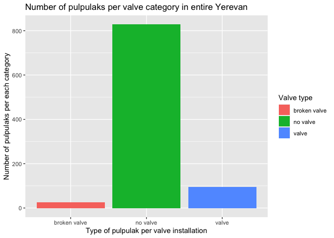

Figure 1: Number of pulpulaks per valve category in entire Yerevan

As we can see from the barplot above, most of the pulpulaks in Yerevan have no valve, i.e. most of the pulpulaks in Yerevan have a continuous flow.

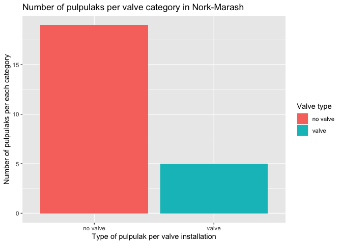

Figure 2: Number of pulpulaks per valve category in Nork-Marash

Here we can see that there are no pulpulaks with broken valves in Nork-Marash district, however again, most of the pulpulaks have no valve, i.e. have continuous flow.

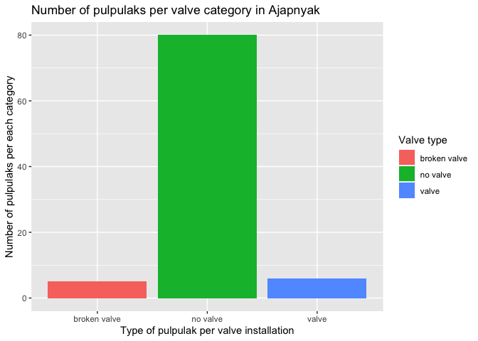

Figure 3: Number of pulpulaks per valve category in Ajapnyak

In Ajapnyak district as well, most of the pulpulaks have no valve.

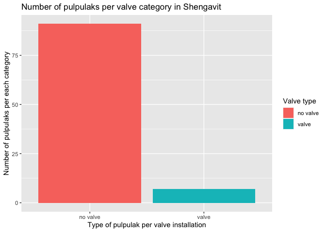

Figure 4: Number of pulpulaks per valve category in Shengavit

In Shengavit district as well, as in previous districts, most of the pulpulaks have no valve. Pay attention that there are no pulpulaks with broken valves.

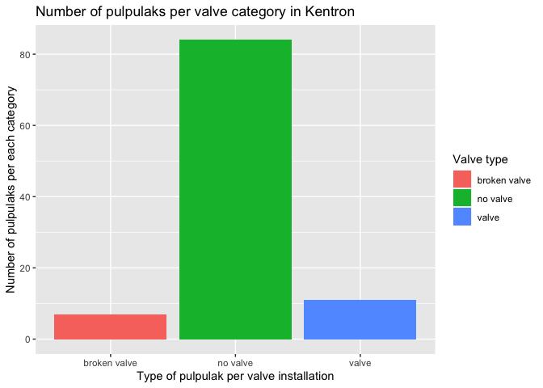

Figure 5: Number of pulpulaks per valve category in Kentron

Most of the pulpulaks in Kentron district too have no valve.

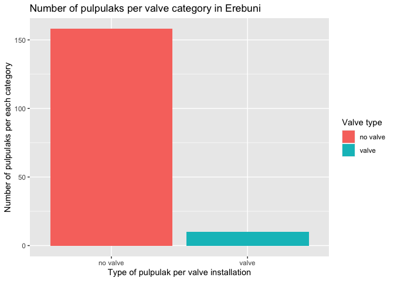

Figure 6: Number of pulpulaks per valve category in Erebuni

Most of the pulpulaks in Erebuni district have no valve. Again, pay attention that there are no pulpulaks with broken valves here.

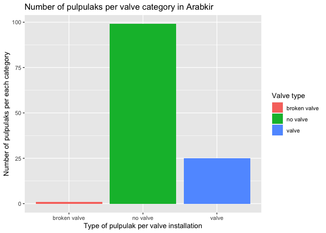

Figure 7: Number of pulpulaks per valve category in Arabkir

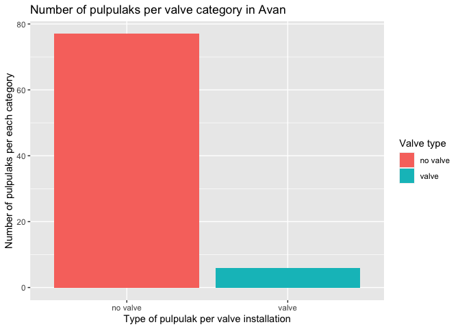

Figure 8: Number of pulpulaks per valve category in Avan

In Avan district too, there are no pulpulaks with broken valves. Most of the pulpulaks have no valve.

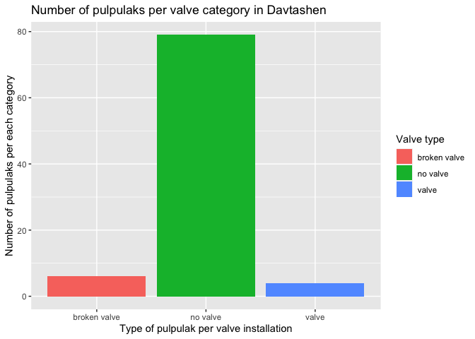

Figure 9: Number of pulpulaks per valve category in Davtashen

In Davtashen district most of the pulpulaks have no valve.

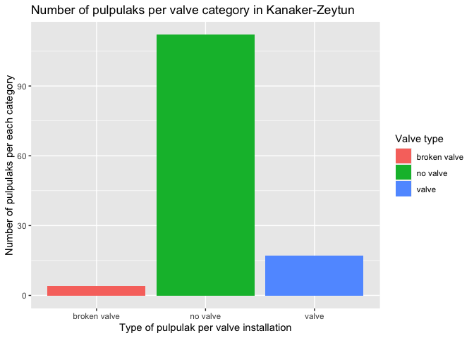

Figure 10: Number of pulpulaks per valve category in Kanaker-Zeytun

Kanaker-Zeytun district as well has mostly pulpulaks with no valves.

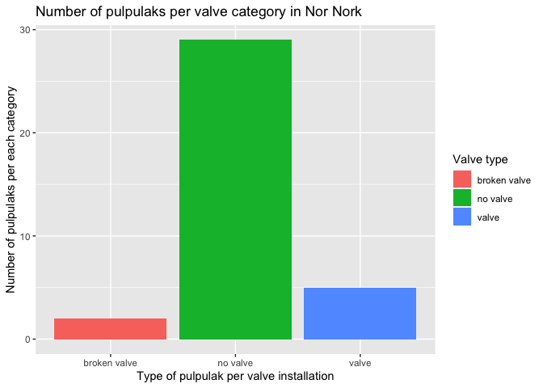

Figure 11: Number of pulpulaks per valve category in Nor Nork

In Nor-Nork district, as in other districts, most of the pulpulaks have no valve.

Evaluation:

Most of the pulpulaks in the Kentron district have no valve. The valves of some of the pulpulaks that have valves are broken.

**2. Taking into account the flow rates from continuously flowing pulpulaks in your dataset, how much water is lost per day in Kentron? How much per year? What are those numbers equivalent to?**

Let’s get to the amount of water lost in Kentron per day and per year and compare it with other forms of water usage. We will obviously exclude the pulpulaks with valves since they are not wasting water.

Before running the numbers, the data was exported and further refined in excel. Let’s get the numbers for water wastage:

The wasted water in Kentron per day is equivalent to about 0.00003% of China’s annual water usage per day.

United States: The total water usage in the United States is around 3,800 billion gallons per day (approximately 14,384,000,000,000 liters per day). The wasted water in Kentron per year is equivalent to about 0.0014% of the daily water usage in the entire United States.

China: China’s total water usage is around 554 billion cubic meters per year (approximately 554,000,000,000,000 liters per year). The wasted water in Kentron per year is equivalent to about 0.00003% of China’s annual water usage.

1. **Describe the distribution of pulpulaks between the different districts. Highlight if there are significant spatial discrepancies in their distribution density. Analyze the potential reasons that lead to these differences.**

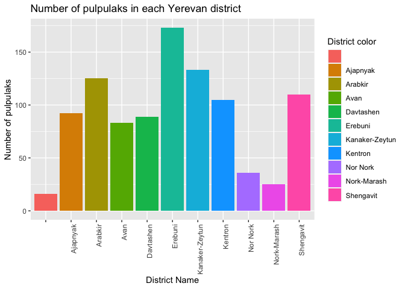

Figure 12: Number of pulpulaks in each Yerevan district

The barplot shows clearly that the most amount of tracked pulpulaks is in Erebuni district and the smallest amount is in Nork-Marash (not counting the pulpulaks from the unnamed area). Looking at the interactive map below, we can see that pulpulaks are located more densely in Kanaker-Zeytun and Arabkir districts.

2. **Develop a methodology to identify where it is more likely to find pulpulaks. Try to find correlations related to some of these factors:**
1. **Road types**
2. **Architecture**
3. **Socioeconomic realities and institutions**
4. **Proximity to certain institutions and entities**
5. **Demographics**
6. **Geography**

**Do your conclusions somehow explain the spatial distribution answered above?**

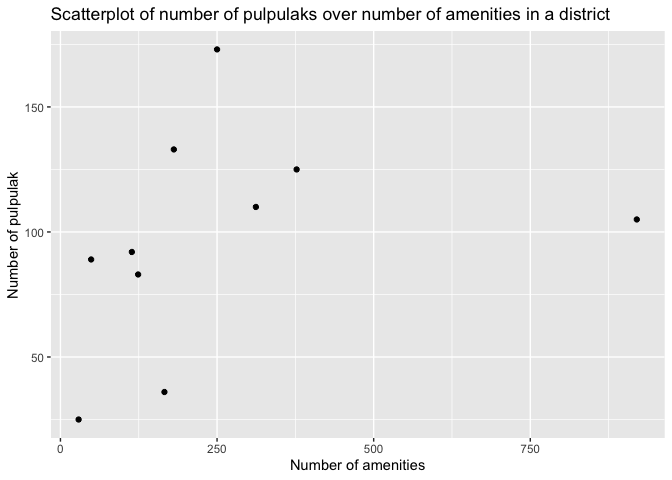

Figure 13: Scatterplot of number of pulpulaks over number of amenities in a district

The graph above shows the correlation between the number of amenities and the number of pulpulaks in each district. As we can see, there is no linear relationship, i.e. no correlation between these two factors, therefore architecture, proximity to certain institutions and entities do not affect the number of pulpulaks in a given area.

[interactive chart not shown]

Map 1: Public pulpulmap of Yerevan

When it comes to geography, we can look at the elevation, and there are no patterns on the elevation map that clearly point out to some sort of correlation between elevation and the number of pulpulaks in a given area.

When it comes to buildings and land use, we can see based on the map that the land use does not matter that much, however all the pulpulaks (at least most of them) are built in a close proximity to buildings. Wherever we see pulpulaks, we can also see buildings nearby.

Currently, there is no information regarding the road types in Yerevan, therefore we cannot make any conclusions at the moment about the correlation between the road types and number of pulpulaks in a given area.

4. **Are there significant differences in flow rates of continuously flowing pulpulaks between different districts? Hypothesize why there may or may not be a difference depending on your answers.**

[figure not shown]

Figure 14: Number of pulpulaks per given flow rate

We can see that in Ajapnyak district the water flow rate of pulpulaks is mostly concetrated around the neighborhood of 2.5 liters per minute. The frequency of flow rate range increases with disruptions(lower bars in between the higher ones that are in the range below 2.5) towards 2.5, reaches its peak around 2.5 and little bit below it and then decreases. There are some outlier flow rate ranges but they do not have a high frequency of appearing in pulpulaks (relatively speaking).

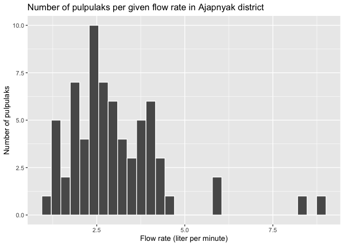

Figure 15: Number of pulpulaks per given flow rate

We can clearly see that most of the pulpulaks in Shengavit district tend to have low flow rates (around or below 1 liter per minute) since the histogram is clearly right skewed. Again, there are some outliers with high flow rates, however their frequency is quite low. So we can confidently say that most of the pulpulaks in Shengavit district maintain low flow rates.

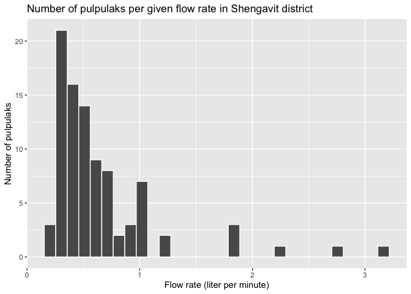

Figure 16: Number of pulpulaks per given flow rate

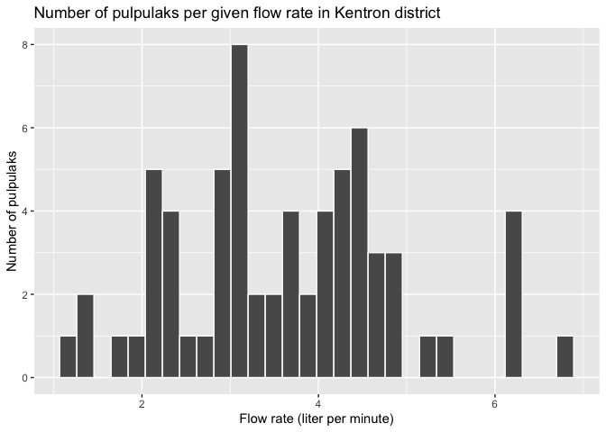

Figure 17: Number of pulpulaks per given flow rate

Even though Erebuni has the most number of pulpulaks among all the districts of Yerevan, we can clearly see that the histogram of the flow rates of pulpulaks in the district is right skewed, i.e. most of the flow rates of pulpulak water fall within small ranges, i.e. the pulpulaks in this district do not use too much of water.

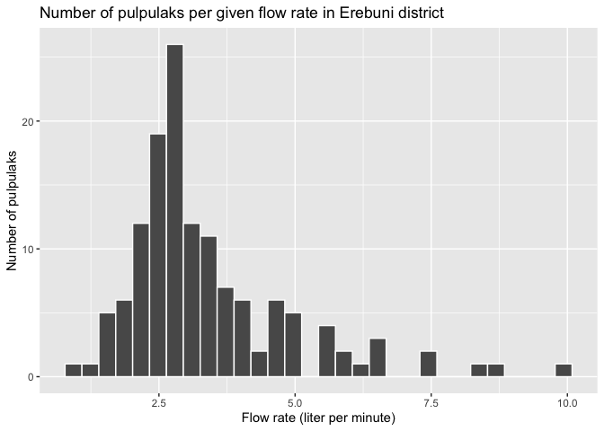

Figure 18: Number of pulpulaks per given flow rate

The flow rates of pulpulak water in Arabkir district, as the ones in Kentron district, are widespread within a broader range. And as in Kentron, so here, the most of the flow rates are concentrated around the neighborhood of 3 liters per minute, a bit more than 4 (4.5) liters per minute. The only difference from the Kentron district here would be the outliers: yes, there are outliers here as well, however, none of them have relatively high frequencies, meanwhile there was one outlier range of flow rate in Kentron, which had a relatively high frequency.

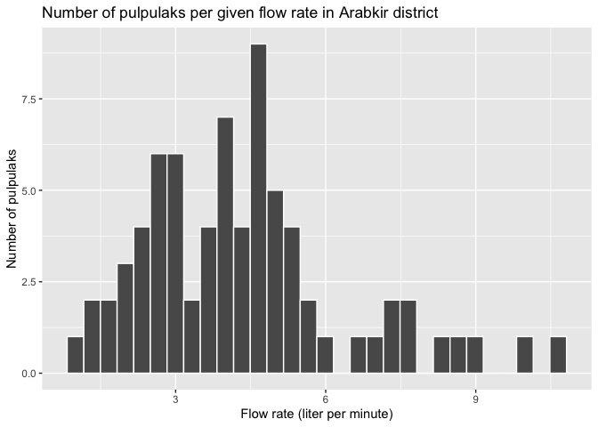

Figure 19: Number of pulpulaks per given flow rate

The flow rates in Avan district are widespread across a bigger range as well. Most of the flow rates of pulpulaks fall within the range just a bit above 2 liters per minute, and above 3.5 liters per minute. However, other ranges also have relatively high frequencies, execpt the outlier range above 5 liter per minute. We could say that in this district, they do not really pay attention to or care about how much the water flow rate of a given pulpulak is.

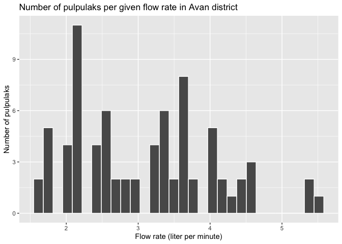

Figure 20: Number of pulpulaks per given flow rate

It can be clearly seen in the histogram its humps(or modes) have shifted more towards right, i.e. higher flow rates. This tells us that in Davtashen districts there are more pulpulaks with higher flow rates than in the previous districts (except maybe Kentron and Arabkir). There are outliers in the histogram, but they fall within either very low or very high ranges, and one of the outliers within the high ranges (a bit above 6 liters per minute) has relatively high frequency. We can confidently state that in Davtashen district, a lot more pulpulaks have higher flow rates than say in Shengavit, Avan and Erebuni.

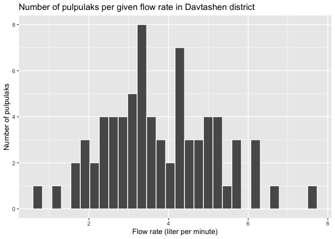

Figure 21: Number of pulpulaks per given flow rate

Most of the pulpulaks in Kanaker-Zeytun district have relatively low flow rates: the majority falls within the range of up to 3.75 liter per minute, even though there are couple of ranges above that threshold that have pretty high frequencies, like the one a bit above 3.75 liter per minute and right by and above 5 liters per minute. So, we can say, that the pulpulaks in this district have mosty low flow rates.

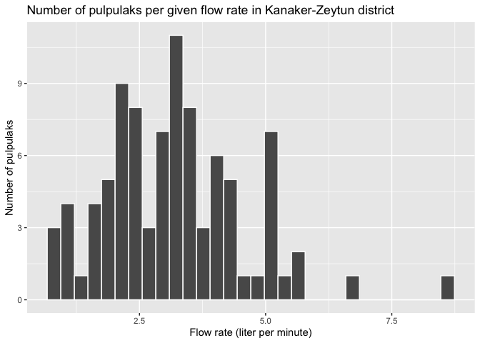

Figure 22: Number of pulpulaks per given flow rate

The pulpulak water flow rate distribution does not follow any certain patterns in Nork-Marash district. We have the highest frequencies within the neighborhood of 2.5 liters per minute, which is considered low, and within the neighborhood of 5 liters per minute, which is considered high.

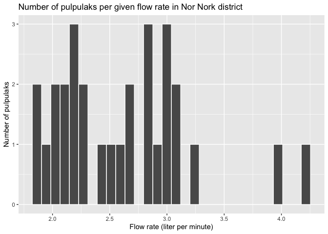

Figure 23: Number of pulpulaks per given flow rate

The histogram clearly indicates that the pulpulak water flow rates in Nor Nork district mostly fall within lower ranges and most of the pulpulaks in this district use less water.

So we can conclude here that the following three district out of all considered districts of Yerevan have the most pulpulaks with higher flow rates (in the following order):

1. Kentron
2. Arabkir
3. Davtashen

In the section below, we will answer the following quantiative questions:

1. Where does the water of pulpulaks come from?
2. Who is responsible for checking the water quality and ensuring drinking water safety standards are respected for pulpulak waters?
3. Who is responsible for maintaining and fixing the pulpulaks?
4. How easy is it to build a new pulpulak? What is the process?

## Qualitative Questions

**1. Where does the water of pulpulaks come from?**

Armenia’s drinking fountains, often called “pulpulaks,” typically get their water from local sources. These sources can include natural springs, wells, or the municipal water supply. To be more specific, the water of the pulpulak comes from the internal networks of the main water supply system entering this residential complex. Water comes to Yerevan from the settlements of Aparan, Hrazdan, Gyumush (Karenis), Getamej, Lusakert, and Garni, as well as from the Azat River basin.

**2. Who is responsible for checking the water quality and ensuring drinking water safety standards are respected for pulpulak waters?**

Before the water reaches populated areas, it enters reservoirs where it is filtered and purified. Responsibility for water quality lies on the water supplier of a given area or city. “Veolia Jur” company is the main water supplier in Armenia, so it is mainly its responsibility to check the quality.

**3. Who is responsible for maintaining and fixing the pulpulaks?**

If a fountain is damaged, it is repaired by the person who built it. Mostly, pulpulaks are built illegally by the local population, so they pay for the repairs. If the fountain was built by a municipality or other institution, then they are the ones who repair it. Naturally, there are also cases when the governing institution of a given area expresses its readiness to repair the pulpulaks, but this in no way shifts responsibility onto them.

**4. How easy is it to build a new pulpulak? What is the process?**

As was already mentioned, in most cases, pulpulaks are built illegally and no one is responsible for it. Especially in recent years, given the war situation and its consequences and the fact that most newly built fountains are dedicated to the memory of the fallen, neither the government nor the water supplier makes any demands on them. In the above case, people simply dig up the ground, find the nearest water pipe, and “rob” water from it. Otherwise, if everything is done legally, an application paper should be submitted to the local water supplier (as well as to the local government if there is a territorial problem), and only after getting permission should the necessary work be carried out. In this case, a meter is installed, and the person responsible for pulpulak pays money for the water consumed. If the fountain is established by a municipality or other government agency, the payer is that agency.

**What is your opinion about pulpulaks’ water quality?**

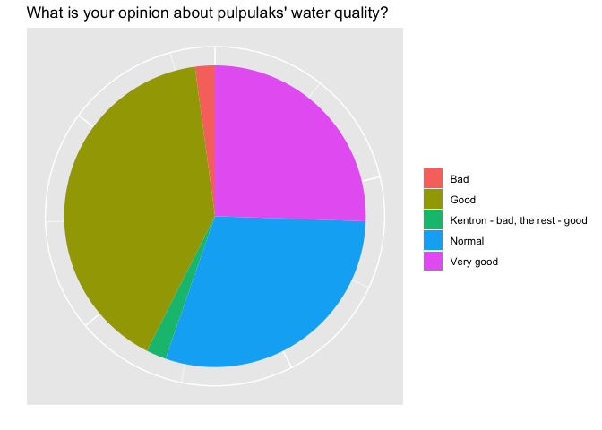

Figure 24: What is your opinion about pulpulaks’ water quality?

```
## [1] "Bad:  1"
```

```
## [1] "Good:  19"
```

```
## [1] "Kentron - bad, the rest - good:  1"
```

```
## [1] "Normal:  14"
```

```
## [1] "Very good:  12"
```

**Armenian pulpulaks together lose 240 million cubic meters of water annually. What do you think about the quantity of water loss?**

**Do you think there is a problem? If yes, what kind of challenges do you foresee and how to mitigate them?**

**Which is the pulpulak in Yerevan that has the tastiest water?**

|  | Armenian pulpulaks together lose 240 million cubic meters of water annually. What do you think about the quantity of water loss? | Do you think there is a problem? If yes, what kind of challenges do you foresee and how to mitigate them? | Which is the pulpulak in Yerevan that has the tastiest water? |
| --- | --- | --- | --- |
| 1 | I think that this number is huge and the problem is that Armenians do not use the water properly and I think if the pulpulaks had valve, this loss would be less. | Yes, the problem is that we use more water then water manages to be filtered so this may result in lack of drinking water. | Pulpulak in Northern Avenue |
| 2 | Chapazanc shat | Ayo pakanov pulupulak vor bacvi erb petka dzmernere pakel vor chsari trubanere chpchana | Mer hayati |
| 3 | even though water is not a scarce resource, it’s not normal to use the resource in such an irresponsible way | lack of clean water | the one on the crossroad of Alek Manukyan and Sayat Nova streets |
| 4 | Շատ տխուր ա | Չկան, գոհ ենք | Հրապարակինը |
| 5 | Ջրի ցավալի կորուստ, որին դեռևս պատշաճ ուշադրություն չեն դարձնում | կարամ ռուսերեն պատասխանեմ? | Պռոշյանի վրինը |
| 6 | Նետրալ | Ձմեռը ջուր չկա, խողովակները սառում են | Բոլորը |
| 7 | Շատ վատ կարծիքի! | Օգտագործել դրանք որպես որոգման ջուր մոտակա տարածքների համար: | Հրապարակի էն Pizza Di Roma ի դեմի մի հատանոց պուլպուլակը, լավ էլ սառն ա! ու համով! |
| 8 | waste | no | Avan |
| 9 | - | I don’t think there is a problem until I have a relevant data to compare analyze and understand how but or impactful it is. | Idk honestly I saw a reel it said in Nubarashen it’s good and in the republic square it’s alright. |
| 10 | shata | Arji krantner dnel pulpulakneri vra | Himnakanum nuynnen |

[output cut: 37 more lines]

Datatable 1: Answers to open ended questions from the survey

The second question was: “Armenian pulpulaks together lose 240 million cubic meters of water annually. What do you think about the quantity of water loss?”. Most people gave very short responses, saying that the loss was too much or disappointing. However, there were people more worried about the situation. Here are some of their responses: -I think that the overall water loss rate in Armenia is too high, and pulpulaks have a huge impact on this phenomenon. The cause of it can be bad water control on pulpulaks because the vast majority of them do not have taps, and they just flow 24/7, which is unnecessary water waste. -Given the problem of drinking water in the world today, I think it would be wise to find options on how we can use it. -THIS IS A HUGE LOSS; WE SHOULD NOT TREAT OUR WATER RESOURCES LIKE THAT -We need water treatment plants -The water loss is very high, that’s why special valves should be installed to control the water flow -Even though water is not a scarce resource, it’s not normal to use the resource in such an irresponsible way -I think that this number is huge, and the problem is that Armenians do not use the water properly. I think if the pulpulaks had a valve, this loss would be less.

In contrast, there were also people who thought there was no water waste, that the amount was small, or simply they didn’t care at all.

The third question was: “Do you think there is a problem? If yes, what kind of challenges do you foresee and how to mitigate them?”. To this question, 8 people answered that there was no problem, and 3 gave no answer. Others answered that the water loss is waste and suggested putting valves on pulpulaks to reduce water loss. Among the problems were also the wrong management of the resources, freezing pipes during the winter and the overuse and lack of clean water.

The fourth question was: “Which pulpulak in Yerevan has the tastiest water?”. Answers to this question were diverse. However, comparably, more voices were given to the pulpulak in Republic Square (“7 Springs”). People who liked the pulpulak in their yard the most were in second place. Other responses are: “Ones in Nor Nork,” “The one near Megamall,” “All,” “Pulpulak in Northern Avenue,” “The one on the crossroad of Alek Manukyan and Sayat Nova streets,” “The one on Proshyan Street,” “Near the Pizza Di Roma, Republic Square,” “Avan,” “Idk honestly I saw a reel it said in Nubarashen,” “Basically they are all the same,” “Tsitsernakaberd”, “AUA park” to name but a few.

**How do you think water in Armenia is priced? (The cost for 1m^3 is about 200 AMD)**

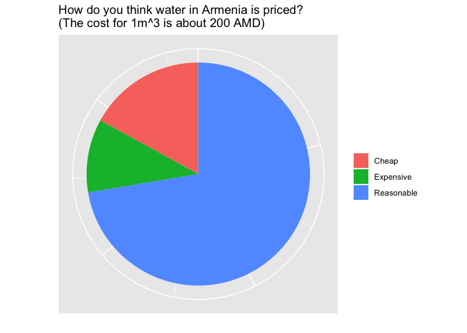

```
## [1] "Cheap:  8"
```

```
## [1] "Expensive:  5"
```

```
## [1] "Reasonable:  34"
```

**What purpose do pulpulaks serve?**

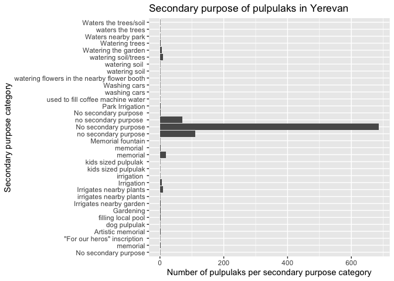

Figure 25: What purpose do pulpulaks serve?

It is clearly seen from the barplot that most of the pulpulaks in Yerevan do not serve any secondary purpose, they are just there as sources of “free” drinking water.

*Summary and discussion:*

*References*

All the data has been collected by the authors of the paper and fellow classmates.